# **The Evolution of Legos Over Time**

Spring 2024 Data Science Project

Patrick Scott

Work split:

Member 1: Patrick Scott, 100%

We, all team members, agree together that the above information is true, and we are confident about our contributions to this submitted project/final tutorial.

Patrick Scott 5/7/2024

I did this entire project by myself.

# **Introduction**

[figure not shown]

Beginning in the 1950s with simple designs and only a handful of parts, Legos have evolved to have complex sets with thousands of small pieces and expanding into covering famous themes such as Star Wars, Harry Potter, and Disney. Additionally, lego have come full circle as a brand and have made their own content based around their products through videogames, movies, and tv shows. One can learn more about the history of lego [here](https://www.lego.com/en-us/aboutus/lego-group/the-lego-group-history).

This project is looking at legos as a product and how they have evolved over the years, going from a simple kids toy to elaborate collectors items and display pieces. As someone who grew up building legos, this transition has often fascinated me as I have seen them change over the years, constantly releasing new sets and developing a brand around display pieces with limited or no play ability such as city skylines and botanicals, which are quite different than the legos I remembered growing up with that focused on being able to play with them as a toy and creativity. That aspect of legos certainly motivated me to do this project around them, as I am curious to see if legos really have changed over the years or if it is just something I have been precieving as a change and not correctly rembering the past. I also think that the question of if legos have become more adult centered over the years is an important one to understand how it may or may not have effected them as a business with a potential change in marketing, as well as seeing a direction legos and other toys may be looking to go in the future.

To start off this project, we will look at the raw data for this project.

# **Data Curation**

The data we are using for this project is from rebrickable, which can be viewed [here.](https://rebrickable.com/downloads/) This dataset was created from information on all lego sets past and present, and has information about the parts in all official lego sets ever created. It contains information about all the lego pieces required in all lego sets.

If one is particularly interested in legos in general, rebrickable also has some great resources on what lego sets can be built using pieces in other sets. Additionally, as lego themselves are constantly releasing new products, the database is constantly being updated to stay as up to date as possible.

To start, a majority of this project will involve pandas and its data frames, so we will need to import it along with some other models which we will touch on later. Pandas is a powerful data science tool built on top of python, that relies on data frames which are essentailly tables. More can be read up on pandas [here](https://pandas.pydata.org/).

```python
import pandas as pd
import statsmodels.api as sm
import matplotlib.pyplot as plt
from sklearn.linear_model import LinearRegression
from sklearn.cluster import KMeans
from sklearn.decomposition import PCA
from scipy.stats import chisquare
```

As the data itself is from a csv file, we simply need to import it into a pandas data frame which we will call sets df using the pandas read_csv function, which turns csv files into pandas dataframes.

```python
setsdf = pd.read_csv('sets.csv')
setsdf.head(10)
```

|  | set_num | name | year | theme_id | num_parts | img_url |
| --- | --- | --- | --- | --- | --- | --- |
| 0 | 0003977811-1 | Ninjago: Book of Adventures | 2022 | 761 | 1 | https://cdn.rebrickable.com/media/sets/0003977... |
| 1 | 001-1 | Gears | 1965 | 756 | 43 | https://cdn.rebrickable.com/media/sets/001-1.jpg |
| 2 | 0011-2 | Town Mini-Figures | 1979 | 67 | 12 | https://cdn.rebrickable.com/media/sets/0011-2.jpg |
| 3 | 0011-3 | Castle 2 for 1 Bonus Offer | 1987 | 199 | 0 | https://cdn.rebrickable.com/media/sets/0011-3.jpg |
| 4 | 0012-1 | Space Mini-Figures | 1979 | 143 | 12 | https://cdn.rebrickable.com/media/sets/0012-1.jpg |
| 5 | 0013-1 | Space Mini-Figures | 1979 | 143 | 12 | https://cdn.rebrickable.com/media/sets/0013-1.jpg |
| 6 | 0014-1 | Space Mini-Figures | 1979 | 143 | 2 | https://cdn.rebrickable.com/media/sets/0014-1.jpg |
| 7 | 0015-1 | Space Mini-Figures | 1979 | 143 | 18 | https://cdn.rebrickable.com/media/sets/0015-1.jpg |
| 8 | 0016-1 | Castle Mini Figures | 1979 | 189 | 15 | https://cdn.rebrickable.com/media/sets/0016-1.jpg |
| 9 | 002-1 | 4.5V Samsonite Gears Motor Set | 1965 | 756 | 3 | https://cdn.rebrickable.com/media/sets/002-1.jpg |

Each row of the dataframe has the following data:

set_num - the official number lego has given the set

name - the name of the lego set

year - the year it was first made

theme_id - the id number for the corresponding theme the set is in, as used in the data set

num_parts - the number of individual lego pieces in the set

image_url - a link to a picture of the box for the lego set. This piece of data is not so necessary for our data analysis, so we can drop it from the dataframe

Additionally, for sets listed as being past 2023 (so with 2024 or 2025 release dates), we will drop them because the entire year has yet to pass, so including them will mess up some of the yearly data beacuse each prior year will have had data for the whole year, while 2024 and 2025 have much less sets listed because 2024 is not yet finished.

```python
setsdf = setsdf.drop(columns=['img_url'])
setsdf = setsdf.drop(setsdf[setsdf['year'] > 2023].index)
```

The other part of data we will want is the themes of each set, which is able to link the theme id of each set in the setsdf to the actual name of the theme.

```python
themesdf = pd.read_csv('themes.csv')
themesdf.head(10)
```

|  | id | name | parent_id |
| --- | --- | --- | --- |
| 0 | 1 | Technic | NaN |
| 1 | 2 | Arctic Technic | 1.0 |
| 2 | 3 | Competition | 1.0 |
| 3 | 4 | Expert Builder | 1.0 |
| 4 | 5 | Model | 1.0 |
| 5 | 6 | Airport | 5.0 |
| 6 | 7 | Construction | 5.0 |
| 7 | 8 | Farm | 5.0 |
| 8 | 9 | Fire | 5.0 |
| 9 | 10 | Harbor | 5.0 |

The different types of data in this dataframe is the following:

id - an integer id for the theme, which matches with the theme_id from the setsdf

name - a string for the name of the theme itself

parent_id - an integer for the parent theme if the theme is a subtheme (ie star wars episode 8 is a subtheme of star wars), not all themes are subthemes so some have no parent id

Next we will add the name of the theme to each entry in the original dataset by merging the datasets on theme_id, so that each set will have the corresponding theme name as part of its entry. Some of the sets don't have their theme represented in the themesdf, so unfortunately will not have the name of the theme displayed, but will still have the information stored in the theme_id. The dataframe with the theme names added is displayed below.

```python
themesdf['theme_id'] = themesdf['id']
themesdf = themesdf.rename(columns={"name": "theme"})
setsdf = pd.merge(setsdf, themesdf, on='theme_id',how='left')
setsdf.head(10)
```

|  | set_num | name | year | theme_id | num_parts | id | theme | parent_id |
| --- | --- | --- | --- | --- | --- | --- | --- | --- |
| 0 | 0003977811-1 | Ninjago: Book of Adventures | 2022 | 761 | 1 | NaN | NaN | NaN |
| 1 | 001-1 | Gears | 1965 | 756 | 43 | NaN | NaN | NaN |
| 2 | 0011-2 | Town Mini-Figures | 1979 | 67 | 12 | 67.0 | Classic Town | 50.0 |
| 3 | 0011-3 | Castle 2 for 1 Bonus Offer | 1987 | 199 | 0 | 199.0 | Lion Knights | 186.0 |
| 4 | 0012-1 | Space Mini-Figures | 1979 | 143 | 12 | 143.0 | Supplemental | 126.0 |
| 5 | 0013-1 | Space Mini-Figures | 1979 | 143 | 12 | 143.0 | Supplemental | 126.0 |
| 6 | 0014-1 | Space Mini-Figures | 1979 | 143 | 2 | 143.0 | Supplemental | 126.0 |
| 7 | 0015-1 | Space Mini-Figures | 1979 | 143 | 18 | 143.0 | Supplemental | 126.0 |
| 8 | 0016-1 | Castle Mini Figures | 1979 | 189 | 15 | 189.0 | Classic Castle | 186.0 |
| 9 | 002-1 | 4.5V Samsonite Gears Motor Set | 1965 | 756 | 3 | NaN | NaN | NaN |

Now we have the data ready to begin some data exploration and basic analysis.

# **Exploratory Data Analysis**

We shall start our data exploration by looking at the number of sets created each year. This is simply done with the value_counts funtion in pandas which counts the number of times each year occurs.

```python
years = setsdf['year'].value_counts()
years
```

```
year
2021    1159
2019    1046
2020    1046
2022    1033
2023    1026
        ...
1950       6
1949       5
1959       4
1953       4
1960       3
Name: count, Length: 73, dtype: int64
```

To create a hypothesis based off of this, we could start with a null hypothesis that the number of sets released each year does not depend on the year, while an alternative hypothesis would be that the number of sets each year is different based on the year.

To help visualize this, we can create a histogram of all the number of sets created each year, using the hist function in pandas.

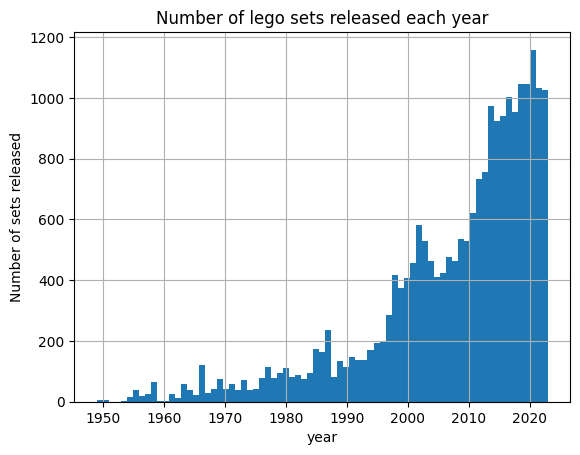

```python
his = setsdf['year'].hist(bins = 75)
his.set_xlabel('year')
his.set_ylabel('Number of sets released')
his.set_title('Number of lego sets released each year')
```

We will go more in depth about how linear regressions work later, if you want to learn more you can jump ahead to the primary analysis section.

```python
model = sm.OLS(setsdf['num_parts'], sm.add_constant(setsdf['year'])).fit()
print(model.summary())
```

```
                            OLS Regression Results
==============================================================================
Dep. Variable:              num_parts   R-squared:                       0.011
Model:                            OLS   Adj. R-squared:                  0.011
Method:                 Least Squares   F-statistic:                     240.5
Date:                Tue, 07 May 2024   Prob (F-statistic):           5.84e-54
Time:                        23:19:41   Log-Likelihood:            -1.6526e+05
No. Observations:               22168   AIC:                         3.305e+05
Df Residuals:                   22166   BIC:                         3.305e+05
Df Model:                           1
Covariance Type:            nonrobust
==============================================================================
                 coef    std err          t      P>|t|      [0.025      0.975]
------------------------------------------------------------------------------
const      -6104.0199    403.975    -15.110      0.000   -6895.840   -5312.200
year           3.1202      0.201     15.509      0.000       2.726       3.515
==============================================================================
Omnibus:                    31401.512   Durbin-Watson:                   1.182
Prob(Omnibus):                  0.000   Jarque-Bera (JB):         13635504.170
Skew:                           8.308   Prob(JB):                         0.00
Kurtosis:                     123.359   Cond. No.                     2.89e+05
==============================================================================

Notes:
[1] Standard Errors assume that the covariance matrix of the errors is correctly specified.
[2] The condition number is large, 2.89e+05. This might indicate that there are
strong multicollinearity or other numerical problems.
```

Next, we can explore the number of pieces each set has. To start, for fun we can look at the largest lego set in the database.

```python
setsdf['num_parts'].max()
```

```
11695
```

As we can see, the biggest lego set ever made has over 11,000 pieces, which is the world map, seen [here](https://www.lego.com/en-us/product/world-map-31203), and pictured below.

[figure not shown]

Next, we can look at the themes. By running value_counts, we can see the number of sets that belong to each one of them.

```python
themes = setsdf['theme'].value_counts()
themes
```

```
theme
Star Wars    919
Technic      868
Key Chain    697
Gear         618
Friends      571
            ...
Universe       2
Samsonite      2
Pirates        1
Aquazone       1
Mini           1
Name: count, Length: 270, dtype: int64
```

A hypothesis we can test from this is if all the themes have roughly the same number of lego sets, which can be tested by a chi squared or goodness of fit test. For this test, the null is that all themes have the same number of sets, and the alternative hypothesis is that they have different numbers of sets. More can be read about how chi squared tests work [here](https://www.bmj.com/about-bmj/resources-readers/publications/statistics-square-one/8-chi-squared-tests). In order to run the test, we can use the chisquare function from scipy.stats, which we imported earlier, and as the function is shown below to get a meaninful output.

```python
chi2_stat, p_value = chisquare(themes)
print(chi2_stat)
print(p_value)
```

```
65127.32042298382
0.0
```

Here, as we would expect, we find a very high chi2 statistic, and a low p value, meaning that the null hypothesis is rejected, and the number of sets in each theme is not the same at a statstically significant level, which would be expected as we see some themes are much larger than others.

To help visualize this, we can create a bar graph of the 20 largest themes, using the plot function from pandas.

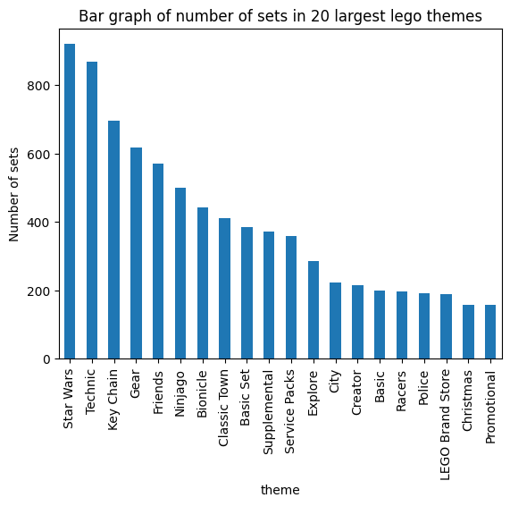

```python
setsdf['theme'].value_counts()[:20].plot(kind = 'bar',ylabel='Number of sets', title='Bar graph of number of sets in 20 largest lego themes')
```

This plot of the twenty largest themes makes it easy to visualize the absolute size of some of the largest ones, with Star Wars and Technic having hundreds of sets. While there is over 250 themes, many of the smaller ones have only a handful of sets, and the following sum function counts the number of times a theme has less than 20 sets, and shows that 138 themes have less than 20.

```python
sum(i < 20 for i in themes)
```

```
138
```

Next, we can look at the number of pieces per set, and how it has changed over the years. We can start with a simple histogram of only the numebr of pieces per set to visualize the distribution of the set.

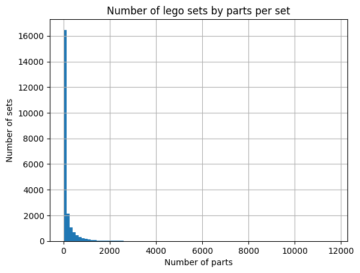

```python
his = setsdf['num_parts'].hist(bins = 90)
his.set_xlabel('Number of parts')
his.set_ylabel('Number of sets')
his.set_title('Number of lego sets by parts per set')
```

Here, we can see that the number of sets is a very skewed distribution, with a vast majority of sets having less than 1000 pieces, while there are still some high outliers that have several thousands.

A simple hypothesis test from this could also be to test if all lego sets have roughly the same number of pieces, also using a chi squared test, where the null hypothesis is that all sets have the same number of pieces, while an alternative would be that the number of pieces varies between sets.

```python
chi2_stat, p_value = chisquare(setsdf['num_parts'])
print(chi2_stat)
print(p_value)
```

```
24350217.088787973
0.0
```

As we would certainly expect from what we saw on the plot, the numer of pieces in each set is significantly not the same for each set, with some very significant outliers of large set.

# **Primary Analysis and Visualizations**

Next we shall begin looking at some machine learning methods to get some more meaningful conclusions about how legos have changed over time. As our main question is looking at how sets have shifted to also cater towards adults more, we can look at how sets have become more complex and have had more pieces over the years.

# **K Means**

While we are trying to classify these lego sets into sets for adults and for kids, there isn't exactly a specific classification given for each of them. Therefore, this is an unspervised learning classification problem, meaning that we need to create our own classifications becuase none are predetermined. We do this by looking at the data and finding ways to split it up. For this tutorial, we will split the data up with the k means algorithm, where the data is split into k clusters, each centered around a specific mean in the data. The algorithm works in a way that each point has a minimal distance to its mean while also having a maximal distance from the points in the other group, to establish clear groupings. More can be read on the process [here.](https://www.analyticsvidhya.com/blog/2019/08/comprehensive-guide-k-means-clustering/)

Additionally, while this can be done with data of any number of dimensions and is often done with several dimensions, we will only be creating means in a one dimensional data set of the number of pieces each set has. We will be creating two clusters, with one being smaller sets intended for kids, and the other being larger sets intended for adults.

To run the actual algorithm, we will be using the KMeans class from the sklearn library of python. The documentation of this class can be read up on [here](https://scikit-learn.org/stable/modules/generated/sklearn.cluster.KMeans.html).

```python
kmeans = KMeans(n_clusters=2, random_state=0, n_init="auto").fit(setsdf[['num_parts']])
means = kmeans.cluster_centers_
means
```

```
array([[ 112.12906058],
       [2163.44781784]])
```

This result from the algorithm shows that the split of clusters from the two groups uses means centered around 112 and 2163 pieces, with the smaller one being our grouping of sets made for kids, and the larger one being our grouping of sets made for adults. Now we can add the category of a set as a small set or large set to our dataframe.

```python
setsdf.insert(2, "category", kmeans.labels_, True)
setsdf['small set'] = setsdf['category'] == 0
setsdf['big set'] = setsdf['category'] == 1
```

The results from this are plotted below, with the first plot being the number of large sets released each year, and the second one being the number of small sets released each year.

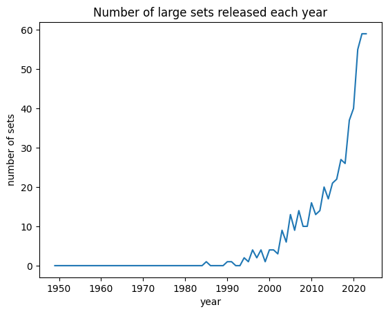

```python
larges = setsdf.groupby('year')['big set'].sum()
larges.plot(xlabel = 'year', ylabel = 'number of sets', title = 'Number of large sets released each year')
```

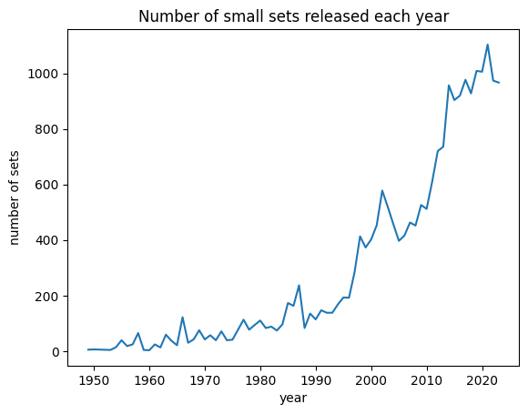

```python
smalls = setsdf.groupby('year')['small set'].sum()
smalls.plot(xlabel = 'year', ylabel = 'number of sets', title = 'Number of small sets released each year')
```

These plots make it easy to visualize the trends in legos, where the number of small large sets released each year has truly taken off quite a bit, starting around 2000 it has gone up very rapidly to where it is now at almost 60 sets each year.

Similarly though, the number of small sets has also grown quite a bit, although not quite as dramatically at the end as the large sets. This reflects the overall trend in the number of sets being released each year going up a lot which was examined in the first part.

# **Linear Regressions**

Next, we will examine this relationship between the number of parts in a set with the year it is released with some linear regression models. Linear regressions are powerful tools to understand the correlation between two different pieces of data, where a line of the form y = mX + b is made from the input data to output data in a way that it is best fit, which is determined by having a line that has the smallest sum of squared errors in the data, where the error is determined as the distance from an actual y value to the prediction the model gives from its X value.

Some more information on the basics of linear regressions can be found [here](https://www.ibm.com/topics/linear-regression#:~:text=IBM-,What%20is%20linear%20regression%3F,is%20called%20the%20independent%20variable.).

If you are interested in how computers actually solve linear least squares problems to get linear regression results, information can be found on that [here](https://machinelearningmastery.com/solve-linear-regression-using-linear-algebra/).

In order to acually solve do linear regressions, we will be using the LinearRegression class from the sklearn library, which we imported earlier, and more can be read up on that class [here](https://scikit-learn.org/stable/modules/generated/sklearn.linear_model.LinearRegression).

```python
reg = LinearRegression().fit(setsdf[['year']],setsdf['num_parts'])
reg.coef_
```

```
array([3.12021043])
```

```python
reg.score(setsdf[['year']],setsdf['num_parts'])
```

```
0.010734142121439305
```

This regression shows that each year the number of parts in each set on average is increasing by 3.1202 pieces. However, as we can see with the R squared score which captures the variance in y that is correlated to x, it is quite low at .0107, meaning that only 1 percent of the variation in number of pieces per set can be found from the year, and there really isn't a very strong trend upwards, making it difficult to draw conclusions from this data.

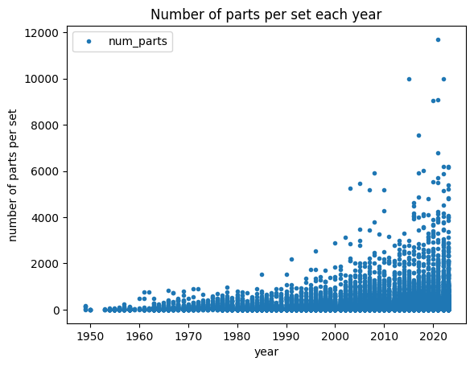

```python
setsdf.plot(x='year', y='num_parts', style='.',ylabel = 'number of parts per set', title = 'Number of parts per set each year')
```

As we have seen in previous analysis and the plot above, the number of sets in general has gone up a lot over time, so while the number of and size of large sets has certainly gone up a lot over the years, so has the number of small sets, which can be bringing down the average number of pieces in each set. Therefore, in order to truly capture the scope of how big legos have grown over time, we can look at instead how the largest set each year has grown, as to not be dragged down by the increasing number of sets in general each year.

```python
max_pieces_df = setsdf.groupby('year')['num_parts'].max().reset_index()
max_pieces_df.columns = ['year', 'largest_set']
reg = LinearRegression().fit(max_pieces_df[['year']],max_pieces_df['largest_set'])
reg.coef_
```

```
array([98.21384734])
```

```python
reg.score(max_pieces_df[['year']],max_pieces_df['largest_set'])
```

```
0.627594021228441
```

Now we can see a significant trend in the way of how the largest sets are growing over time, with the largest set growing by 98 pieces each year. Additionally, the R squared score shows that there is a significant correlation between the year and the number of pieces in the largest set.

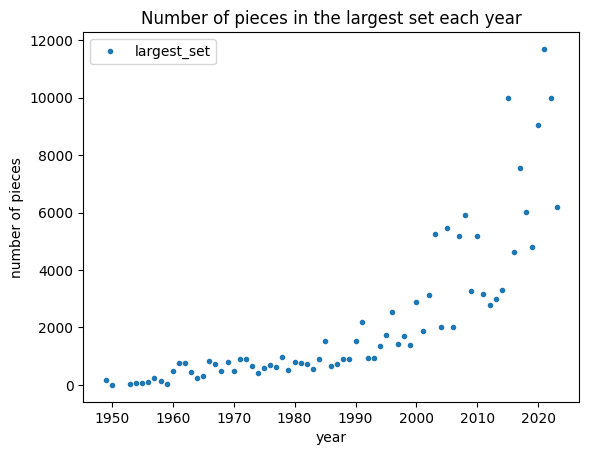

```python
max_pieces_df.plot(x='year', y='largest_set', style='.',ylabel= 'number of pieces',title='Number of pieces in the largest set each year')
```

This plot makes it much easier to see the upward trajectory of sets being released each year, where the upward trend with time is much stronger.

Overall the results of these last two regressions seem to imply that while lego has been building larger sets, they have also been building smaller ones too, and are simply branching in many different directions. This will be further seen as we examine the way lego themes have grown over time.

Each year, lego releases new themes, and that can be seen in the graph below which captures the number of themes being made each year.

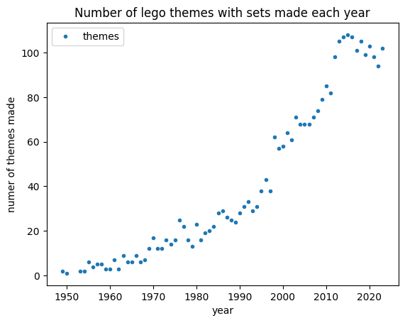

```python
themes_per_year = setsdf.groupby(setsdf['year'])['theme_id'].nunique().reset_index()
themes_per_year.columns = ['year', 'themes']
themes_per_year.plot(x='year',y='themes',style='.', ylabel = 'numer of themes made', title = 'Number of lego themes with sets made each year')
```

```python
reg = LinearRegression().fit(themes_per_year[['year']],themes_per_year['themes'])
reg.coef_
```

```
array([1.58321563])
```

This regression shows that each year about 1.5 more themes are represented than the year prior, showing how lego as a brand have been branching out over time.

# **Conclusions**

So, looking at legos over time it is clear to see that they have evolved a lot from when they first stated out. Not only are there larger being made now than when lego first started as we have seen multiple times through the data, the variety of legos in general has really exploded over the past 25 years. The number of themes lego has show this very well, as legos have a strong reach across a great spectrum of possibilities for the brick built world. Additionally the willingness of lego to create larger sets opens them up for more possibilities. Since I first got my first lego set back in 2010, I have seen the brand do many exciting new things.

But, relating back to my original research question of if legos have become more adult centered, what I will say is it is complicated. I have shown that legos have created more large sets, and the expansion of themes does often include themes that are more focused for the nice interests of adults and collectors looking for legos as a display piece rather than a toy to play with. In the way that large sets with thousands of pieces are more common today than ever before, I would say that legos are more focused on adults as an audience now than they were when they first started, creating sets that require lots of focus and attention (not to mention hefty price tags) that are often a barrier for kids to get these giant sets, that are instead clearly marketed for adults.

That being said, the data also shows that legos of all types are more prevelant now than before. While there are more larger sets, there are also more smaller sets, and while some of the new themes are centered around being display pieces and valuable collectables, there are also many new themes which emphasize playability and accessibility for younger kids to enjoy them (speaking more from my personal knowledge and not so much the data here). Perhaps a more accurate way of stating it is that legos as a brand have branched into many different areas, and adding adding larger sets for adults as collector items is simply one of the ways it is branching out.

Anyways, I hope you enjoyed this and were able to learn a bit about legos and/or the data science and machine learning process.

[figure not shown]